# **ML Final Review**

## TEAM MEMBERS:

## NISCHIT K R - 20BAI1159

## SHIVAPRAKASH SHIVAKUMARASWAMY JAYACHAMARAJAPURA- 20BAI1205

## ROHAN ALROY.B - 20BAI1245

## Importing Libraries

```python
import numpy as np
import math
import pandas as pd
import datetime
import matplotlib.pyplot as plt
import matplotlib.cm as cm
%matplotlib inline
from matplotlib.axes._axes import _log as matplotlib_axes_logger
matplotlib_axes_logger.setLevel('ERROR')

import seaborn as sns
sns.set_style("dark")
from matplotlib.pyplot import pie, axis, show
from sklearn import preprocessing
from scipy.stats import skew, boxcox
from sklearn import metrics
import warnings
```

## Reading the data

```python
data = pd.read_csv("sampled_fraud.csv")
```

```python
data.shape
```

```
(100000, 12)
```

```python
data.head()
```

|  | Unnamed: 0 | step | type | amount | nameOrig | oldbalanceOrg | newbalanceOrig | nameDest | oldbalanceDest | newbalanceDest | isFraud | isFlaggedFraud |
| --- | --- | --- | --- | --- | --- | --- | --- | --- | --- | --- | --- | --- |
| 0 | 263314 | 15 | PAYMENT | 22726.39 | C1444634854 | 0.00 | 0.00 | M1897335016 | 0.00 | 0.00 | 0.0 | 0.0 |
| 1 | 871831 | 42 | PAYMENT | 11520.44 | C1543928118 | 0.00 | 0.00 | M1447434896 | 0.00 | 0.00 | 0.0 | 0.0 |
| 2 | 488155 | 19 | PAYMENT | 18387.10 | C1637229477 | 0.00 | 0.00 | M1263657510 | 0.00 | 0.00 | 0.0 | 0.0 |
| 3 | 231470 | 14 | PAYMENT | 7594.83 | C2068036489 | 0.00 | 0.00 | M485877510 | 0.00 | 0.00 | 0.0 | 0.0 |
| 4 | 1049672 | 95 | CASH_IN | 29754.17 | C1149489060 | 5424630.06 | 5454384.23 | C2089313881 | 695026.65 | 665272.48 | 0.0 | 0.0 |

```python
data.isnull().sum()
```

```
Unnamed: 0        0
step              0
type              0
amount            0
nameOrig          0
oldbalanceOrg     0
newbalanceOrig    0
nameDest          0
oldbalanceDest    0
newbalanceDest    0
isFraud           0
isFlaggedFraud    0
dtype: int64
```

```python
data.info()
```

```
<class 'pandas.core.frame.DataFrame'>
RangeIndex: 100000 entries, 0 to 99999
Data columns (total 12 columns):
 #   Column          Non-Null Count   Dtype
---  ------          --------------   -----
 0   Unnamed: 0      100000 non-null  int64
 1   step            100000 non-null  int64
 2   type            100000 non-null  object
 3   amount          100000 non-null  float64
 4   nameOrig        100000 non-null  object
 5   oldbalanceOrg   100000 non-null  float64
 6   newbalanceOrig  100000 non-null  float64
 7   nameDest        100000 non-null  object
 8   oldbalanceDest  100000 non-null  float64
 9   newbalanceDest  100000 non-null  float64
 10  isFraud         100000 non-null  float64
 11  isFlaggedFraud  100000 non-null  float64
dtypes: float64(7), int64(2), object(3)
memory usage: 9.2+ MB
```

```python
data['type'].value_counts()
```

```
CASH_OUT    35451
PAYMENT     33339
CASH_IN     22096
TRANSFER     8403
DEBIT         711
Name: type, dtype: int64
```

```python
data.describe()
```

|  | Unnamed: 0 | step | amount | oldbalanceOrg | newbalanceOrig | oldbalanceDest | newbalanceDest | isFraud | isFlaggedFraud |
| --- | --- | --- | --- | --- | --- | --- | --- | --- | --- |
| count | 1.000000e+05 | 100000.000000 | 1.000000e+05 | 1.000000e+05 | 1.000000e+05 | 1.000000e+05 | 1.000000e+05 | 100000.000000 | 100000.0 |
| mean | 6.753357e+05 | 50.215320 | 1.634388e+05 | 8.795008e+05 | 8.997089e+05 | 9.973746e+05 | 1.127852e+06 | 0.001350 | 0.0 |
| std | 3.890061e+05 | 45.580149 | 2.792394e+05 | 2.976294e+06 | 3.012209e+06 | 2.332881e+06 | 2.446659e+06 | 0.036718 | 0.0 |
| min | 3.700000e+01 | 1.000000 | 2.600000e-01 | 0.000000e+00 | 0.000000e+00 | 0.000000e+00 | 0.000000e+00 | 0.000000 | 0.0 |
| 25% | 3.367535e+05 | 16.000000 | 1.312682e+04 | 0.000000e+00 | 0.000000e+00 | 0.000000e+00 | 0.000000e+00 | 0.000000 | 0.0 |
| 50% | 6.782070e+05 | 36.000000 | 7.892166e+04 | 1.588600e+04 | 0.000000e+00 | 1.311405e+05 | 2.240442e+05 | 0.000000 | 0.0 |
| 75% | 1.011970e+06 | 46.000000 | 2.184368e+05 | 1.353456e+05 | 1.745209e+05 | 9.331220e+05 | 1.155101e+06 | 0.000000 | 0.0 |
| max | 1.347661e+06 | 137.000000 | 1.000000e+07 | 3.729746e+07 | 3.753800e+07 | 3.985396e+07 | 4.138365e+07 | 1.000000 | 0.0 |

```python
#Total number of unique customers
print(f"Total number of unique customers are {data.nameOrig.nunique()}")
print(f"Total number of unique recipients are {data.nameDest.nunique()}")
print(f"Average no. of transactions per customer are {data.shape[0]/data.nameOrig.nunique()}")
print(f"Average no. of transactions per recipient are {data.shape[0]/data.nameDest.nunique()}")
```

```
Total number of unique customers are 99998
Total number of unique recipients are 77195
Average no. of transactions per customer are 1.000020000400008
Average no. of transactions per recipient are 1.2954206878683852
```

# EXPLORATORY DATA ANALYSIS

# Through the exploratory data analysis, we can prove some hypothesis about fraud attacks and get some visual interpretations from data.

# Plotting different types of transactions

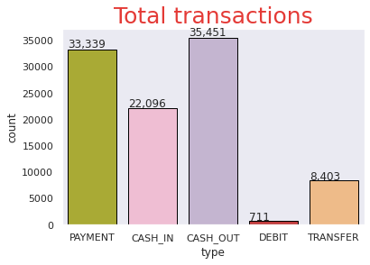

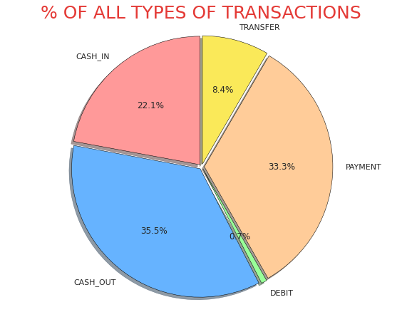

```python
fig, ax = plt.subplots()
plt.rcParams['figure.figsize'] = (20, 16)
sns.set_theme(style="whitegrid")
tips = sns.load_dataset("tips")
sns.countplot(x='type', data=data,palette="tab20_r",edgecolor='black')
for p in ax.patches:
    ax.annotate(str(format(int(p.get_height()), ',d')), (p.get_x(), p.get_height()*1.01))
plt.title('Total transactions',fontsize=25,color='#E43A36')
df_pie=data.groupby(['type']).size()
#axis('equal');
#pie(df_pie, labels=df_pie.index);
# Pie chart
plt.rcParams['figure.figsize'] = (8, 6)
labels = df_pie.index
sizes = df_pie
# only "explode" the 2nd slice (i.e. 'Hogs')
explode = (0.02, 0.02, 0.02, 0.02,0.02)
#add colors
colors = ['#ff9999','#66b3ff','#99ff99','#ffcc99','#FAE959']
fig1, ax1 = plt.subplots()
ax1.pie(sizes, explode=explode, labels=labels, colors=colors, autopct='%1.1f%%',
        shadow=True, startangle=90,wedgeprops={"edgecolor":"0",'linewidth': 0.5,'linestyle': 'solid', 'antialiased': True})
# Equal aspect ratio ensures that pie is drawn as a circle
ax1.axis('equal')
plt.tight_layout()
plt.title('% OF ALL TYPES OF TRANSACTIONS',fontsize=25,color='#E43A36')
plt.show()
```

```
array([[<matplotlib.axes._subplots.AxesSubplot object at 0x7f52e8e310d0>,
      dtype=object)
```

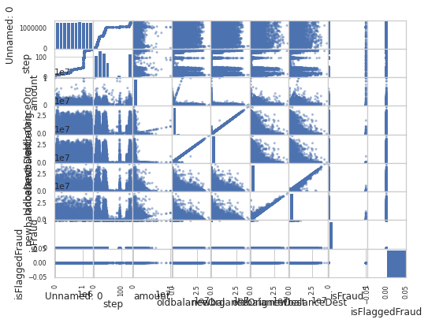

```python
pd.plotting.scatter_matrix(data)
```

```python
data.corr()["isFraud"].sort_values(ascending = False)
```

```
isFraud           1.000000
amount            0.186638
Unnamed: 0        0.013084
step              0.010480
oldbalanceOrg     0.009354
newbalanceDest    0.004594
oldbalanceDest   -0.009741
newbalanceOrig   -0.010234
isFlaggedFraud         NaN
Name: isFraud, dtype: float64
```

```
0.0    99865
1.0      135
Name: isFraud, dtype: int64
```

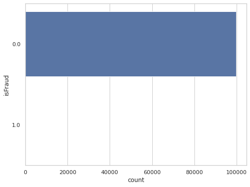

```python
print(data["isFraud"].value_counts())
sns.countplot(y="isFraud",data=data)
plt.show()
```

```python
data['type'].value_counts()
```

```
CASH_OUT    35451
PAYMENT     33339
CASH_IN     22096
TRANSFER     8403
DEBIT         711
Name: type, dtype: int64
```

```python
data['type'] = data['type'].map({'CASH_OUT':1,'PAYMENT':2,'CASH_IN':3,'TRANSFER':4,'DEBIT':5})
```

```python
x = data[['type','amount','oldbalanceOrg','newbalanceOrig']]
x
```

|  | type | amount | oldbalanceOrg | newbalanceOrig |
| --- | --- | --- | --- | --- |
| 0 | 2 | 22726.39 | 0.00 | 0.00 |
| 1 | 2 | 11520.44 | 0.00 | 0.00 |
| 2 | 2 | 18387.10 | 0.00 | 0.00 |
| 3 | 2 | 7594.83 | 0.00 | 0.00 |
| 4 | 3 | 29754.17 | 5424630.06 | 5454384.23 |
| ... | ... | ... | ... | ... |
| 99995 | 3 | 291668.23 | 4117328.56 | 4408996.79 |
| 99996 | 3 | 192405.71 | 252337.00 | 444742.71 |
| 99997 | 1 | 19285.93 | 0.00 | 0.00 |
| 99998 | 2 | 24094.45 | 838159.96 | 814065.51 |
| 99999 | 3 | 13773.86 | 614279.77 | 628053.63 |

100000 rows × 4 columns

```python
y = data['isFraud']
y
```

```
0        0.0
1        0.0
2        0.0
3        0.0
4        0.0
        ...
99995    0.0
99996    0.0
99997    0.0
99998    0.0
99999    0.0
Name: isFraud, Length: 100000, dtype: float64
```

```python
y.count()
```

```
100000
```

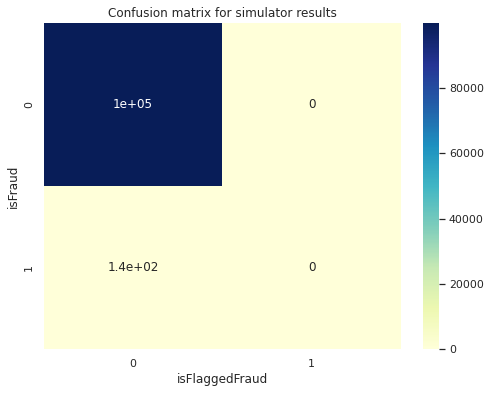

```python
y_true = list(data['isFraud'])
y_pred = list(data['isFlaggedFraud'])
cf_matrix = metrics.confusion_matrix(y_true, y_pred)
sns.heatmap(cf_matrix, annot=True, cmap='YlGnBu')
plt.xlabel("isFlaggedFraud")
plt.ylabel("isFraud")
plt.title("Confusion matrix for simulator results")
```

# Plotting types of transactions which fall under the Fraud category

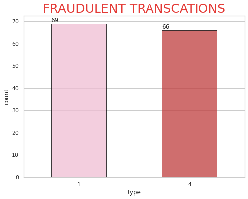

```python
fig, ax = plt.subplots()
df_fraud=data[data['isFraud']==1]
sns.countplot(x='type',data=df_fraud, ax=ax,palette="tab20_r",edgecolor='black',alpha=0.75)
def change_width(ax, new_value) :
    for patch in ax.patches :
        current_width = patch.get_width()
        diff = current_width - new_value

        # we change the bar width
        patch.set_width(new_value)

        # we recenter the bar
        patch.set_x(patch.get_x() + diff * .5)

change_width(ax, .5)
for p in ax.patches:
    ax.annotate(str(format(int(p.get_height()), ',d')), (p.get_x(), p.get_height()*1.01))
plt.title('FRAUDULENT TRANSCATIONS',fontsize=25,color='#E43A36')
plt.show()
```

There are only two types of transcations which fall under fraud category as shown in the above bar plot

There are two types of transactions based on Recipients, One is normal customer and the other one is Merchant, with simple checking it was found that all the transactions pertaining with the Merchants were legit and none of them was found to be fraud, same is described in the below pie chart.

```python
df = data.copy()
df['percentage'] = np.where(df['amount']>df['oldbalanceOrg'], 100.0, (df['amount']/df['oldbalanceOrg'])*100)
df['dest']=df['nameDest'].astype(str).str[0]
```

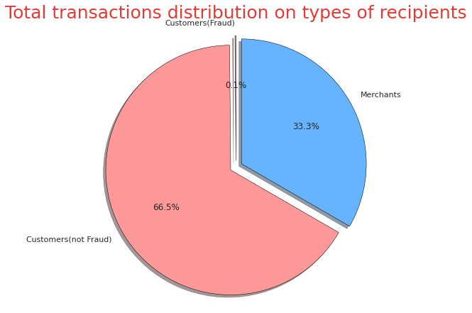

```python
list1=list(df[df['isFraud']==1].groupby(['dest']).size())
list2=list(df[df['isFraud']==0].groupby(['dest']).size())
newlist=list1+list2
newlist
plt.rcParams['figure.figsize'] = (8, 6)
labels = ['Customers(Fraud)','Customers(not Fraud)','Merchants']
sizes = newlist
# only "explode" the 2nd slice (i.e. 'Hogs')
explode = (0.05,0.05, 0.05)
#add colors
colors = ['#ff9999','#ff9999','#66b3ff']
fig1, ax1 = plt.subplots()
ax1.pie(sizes, explode=explode, labels=labels, colors=colors, autopct='%1.1f%%',
        shadow=True, startangle=90,wedgeprops={"edgecolor":"0",'linewidth': 0.5,'linestyle': 'solid', 'antialiased': True})
# Equal aspect ratio ensures that pie is drawn as a circle
ax1.axis('equal')
plt.tight_layout()
plt.title('Total transactions distribution on types of recipients',fontsize=25,color='#E43A36',)
plt.show()
```

There are in total about 0.1% transactions and all are in the Customer's Category

# Plotting heatmap to check correlation between different parameters

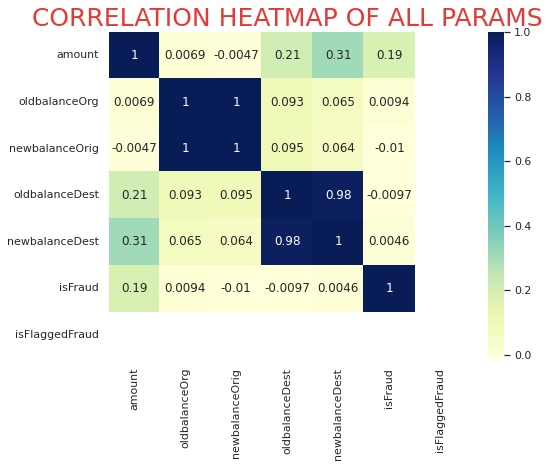

```python
df_heatmap = data[['amount','oldbalanceOrg','newbalanceOrig','oldbalanceDest','newbalanceDest','isFraud','isFlaggedFraud']]
sns.heatmap(df_heatmap.corr(), cmap="YlGnBu", annot=True)
plt.title('CORRELATION HEATMAP OF ALL PARAMS',fontsize=25,color='#E43A36')
```

Fraud category has more dependence on Amount category, we will try to plot it

# Scatter Plot between Amount and Balance, highlighting the fraud transaction

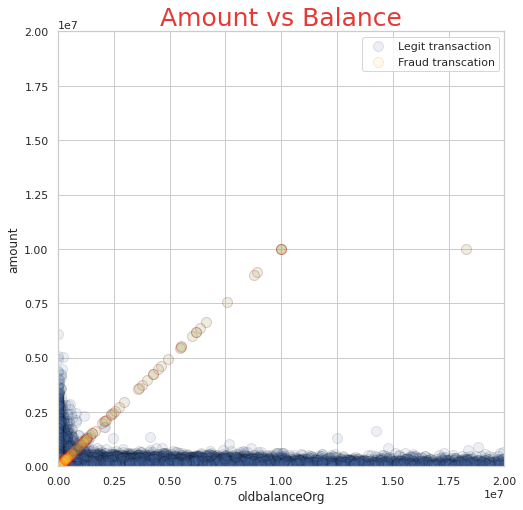

```python
newscatplot=df[df['isFraud']==1]
plt.figure(figsize=(8,8))
ax = plt.gca()
ax.set_ylim(0,2*1e7)
ax.set_xlim(0,2*1e7)
df.plot.scatter(x='oldbalanceOrg',y='amount', ax=ax,edgecolors='black',s=100,alpha=0.1,label="Legit transaction")
newscatplot.plot.scatter(x='oldbalanceOrg',y='amount', color='#FCD735', ax=ax,edgecolors='red',s=100,alpha=0.1,label="Fraud transcation")
plt.title('Amount vs Balance',fontsize=25,color='#E43A36')
```

There are various inferences from the above graph

Firstly,The fraud line is inclined equally from both axis which implies that whenever the amount dealt was equal to the balance, it was most likely a Fraud

After a while the fraud line hits a constant limit, which implies that there is limit in some form to the maximum amount which can be CASH OUT or TRANSFER, hence there are no fraud amounts which surpass this limit

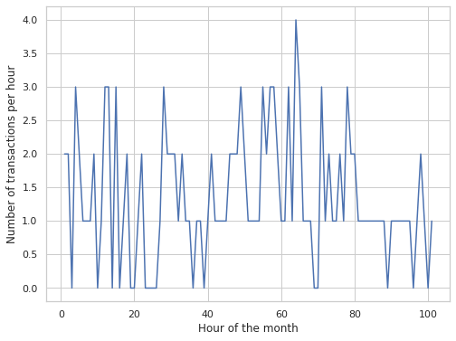

```python
sns.lineplot(x=list(range(1,102)),y=data.groupby("step")["isFraud"].sum())
plt.xlabel("Hour of the month")
plt.ylabel("Number of transactions per hour")
plt.show()
```

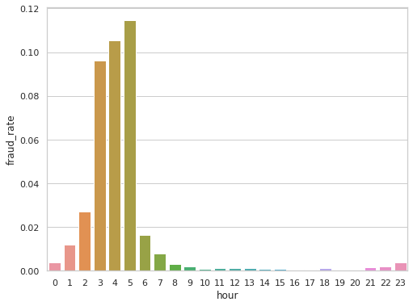

```python
data["hour"] = data.step % 24
frauds_hour = pd.concat([data.groupby("hour")["isFraud"].sum(),data.groupby("hour")["isFraud"].count()],axis=1)
frauds_hour.columns = ["Frauds","Transactions"]
frauds_hour["fraud_rate"] = frauds_hour.Frauds/frauds_hour.Transactions
sns.barplot(x=frauds_hour.index,y=frauds_hour.fraud_rate)
plt.show()
```

## Preprocessing

**To prevent data leakage we drop isFlaggedFraud**

```python
data = data.drop("isFlaggedFraud", axis = 1)
data.info()
```

```
<class 'pandas.core.frame.DataFrame'>
RangeIndex: 100000 entries, 0 to 99999
Data columns (total 12 columns):
 #   Column          Non-Null Count   Dtype
---  ------          --------------   -----
 0   Unnamed: 0      100000 non-null  int64
 1   step            100000 non-null  int64
 2   type            100000 non-null  int64
 3   amount          100000 non-null  float64
 4   nameOrig        100000 non-null  object
 5   oldbalanceOrg   100000 non-null  float64
 6   newbalanceOrig  100000 non-null  float64
 7   nameDest        100000 non-null  object
 8   oldbalanceDest  100000 non-null  float64
 9   newbalanceDest  100000 non-null  float64
 10  isFraud         100000 non-null  float64
 11  hour            100000 non-null  int64
dtypes: float64(6), int64(4), object(2)
memory usage: 9.2+ MB
```

**Converting Categorical variables to numerical ones**

Making dummy variables for type

```python
types = pd.get_dummies(data["type"],drop_first = True)
data.drop("type",axis = 1,inplace = True)
```

```python
data = pd.concat([data, types], axis = 1)
data.info()
```

```
<class 'pandas.core.frame.DataFrame'>
RangeIndex: 100000 entries, 0 to 99999
Data columns (total 15 columns):
 #   Column          Non-Null Count   Dtype
---  ------          --------------   -----
 0   Unnamed: 0      100000 non-null  int64
 1   step            100000 non-null  int64
 2   amount          100000 non-null  float64
 3   nameOrig        100000 non-null  object
 4   oldbalanceOrg   100000 non-null  float64
 5   newbalanceOrig  100000 non-null  float64
 6   nameDest        100000 non-null  object
 7   oldbalanceDest  100000 non-null  float64
 8   newbalanceDest  100000 non-null  float64
 9   isFraud         100000 non-null  float64
 10  hour            100000 non-null  int64
 11  2               100000 non-null  uint8
 12  3               100000 non-null  uint8
 13  4               100000 non-null  uint8
 14  5               100000 non-null  uint8
dtypes: float64(6), int64(3), object(2), uint8(4)
memory usage: 8.8+ MB
```

Hashing nameOrig and nameDest

```python
data["nameOrig"] = pd.util.hash_array(data["nameOrig"].to_numpy())
data["nameDest"] = pd.util.hash_array(data["nameDest"].to_numpy())
```

**Normalizing the data**

```python
data.head(20)
```

|  | Unnamed: 0 | step | amount | nameOrig | oldbalanceOrg | newbalanceOrig | nameDest | oldbalanceDest | newbalanceDest | isFraud | hour | 2 | 3 | 4 | 5 |
| --- | --- | --- | --- | --- | --- | --- | --- | --- | --- | --- | --- | --- | --- | --- | --- |
| 0 | 263314 | 15 | 22726.39 | 9089039905814941322 | 0.00 | 0.00 | 12668397161262859528 | 0.00 | 0.00 | 0.0 | 15 | 1 | 0 | 0 | 0 |
| 1 | 871831 | 42 | 11520.44 | 16840207302583419675 | 0.00 | 0.00 | 2263106185704015334 | 0.00 | 0.00 | 0.0 | 18 | 1 | 0 | 0 | 0 |
| 2 | 488155 | 19 | 18387.10 | 11282266707886495532 | 0.00 | 0.00 | 13333603264116280995 | 0.00 | 0.00 | 0.0 | 19 | 1 | 0 | 0 | 0 |
| 3 | 231470 | 14 | 7594.83 | 15710338795348639928 | 0.00 | 0.00 | 1579900591520468888 | 0.00 | 0.00 | 0.0 | 14 | 1 | 0 | 0 | 0 |
| 4 | 1049672 | 95 | 29754.17 | 17174611394552008114 | 5424630.06 | 5454384.23 | 229208366736463232 | 695026.65 | 665272.48 | 0.0 | 23 | 0 | 1 | 0 | 0 |
| 5 | 280633 | 15 | 104154.79 | 10310216801858866015 | 4100312.33 | 4204467.11 | 7707544501319264182 | 1585439.31 | 1481284.52 | 0.0 | 15 | 0 | 1 | 0 | 0 |
| 6 | 723395 | 37 | 56184.76 | 18351092320436870300 | 48622.10 | 0.00 | 17080986378922540675 | 1037196.09 | 1093380.84 | 0.0 | 13 | 0 | 0 | 0 | 0 |
| 7 | 1144972 | 131 | 40137.31 | 13105313387229328029 | 214295.00 | 174157.69 | 16912932319311265646 | 0.00 | 40137.31 | 0.0 | 11 | 0 | 0 | 0 | 0 |
| 8 | 898153 | 42 | 301161.03 | 13353997973738519917 | 2408177.37 | 2709338.41 | 9506826830037576576 | 1804447.75 | 1503286.71 | 0.0 | 18 | 0 | 1 | 0 | 0 |
| 9 | 186213 | 13 | 238162.86 | 6181062251487541315 | 22289.00 | 0.00 | 7534665763603546395 | 655039.18 | 893202.04 | 0.0 | 13 | 0 | 0 | 0 | 0 |
| 10 | 1183519 | 132 | 34570.01 | 9526110852164306508 | 0.00 | 0.00 | 16119889202192629840 | 0.00 | 0.00 | 0.0 | 12 | 1 | 0 | 0 | 0 |
| 11 | 577368 | 33 | 275696.24 | 3165491895041443874 | 0.00 | 0.00 | 14829906202354731711 | 709924.51 | 985620.75 | 0.0 | 9 | 0 | 0 | 0 | 0 |
| 12 | 623353 | 34 | 79095.23 | 18263683059877763579 | 0.00 | 0.00 | 9712764928386910181 | 0.00 | 79095.23 | 0.0 | 10 | 0 | 0 | 0 | 0 |
| 13 | 589121 | 33 | 4299.56 | 6294032939530959976 | 11548.00 | 7248.44 | 10100641199096704520 | 804742.75 | 809042.32 | 0.0 | 9 | 0 | 0 | 0 | 1 |
| 14 | 1261822 | 134 | 185129.64 | 7154026016216429281 | 7102707.26 | 7287836.90 | 8806604739177351462 | 431555.53 | 246425.89 | 0.0 | 14 | 0 | 1 | 0 | 0 |
| 15 | 1122547 | 130 | 103033.25 | 1602236825532757866 | 0.00 | 0.00 | 7676249610529382717 | 628664.86 | 731698.11 | 0.0 | 10 | 0 | 0 | 0 | 0 |
| 16 | 56620 | 9 | 89340.37 | 153483167523479428 | 0.00 | 0.00 | 440403280477911044 | 401307.20 | 520691.70 | 0.0 | 9 | 0 | 0 | 0 | 0 |
| 17 | 842957 | 41 | 65666.91 | 3917425147552810649 | 106048.00 | 40381.09 | 8570170129491966919 | 417891.42 | 483558.33 | 0.0 | 17 | 0 | 0 | 0 | 0 |
| 18 | 21482 | 8 | 235759.50 | 9730902195147640529 | 0.00 | 0.00 | 2763563209754452678 | 1925768.06 | 1983599.05 | 0.0 | 8 | 0 | 0 | 0 | 0 |
| 19 | 503055 | 20 | 10198.65 | 9666062162183138499 | 12193.00 | 1994.35 | 2840726168735027471 | 0.00 | 0.00 | 0.0 | 20 | 1 | 0 | 0 | 0 |

```python
from sklearn.preprocessing import MinMaxScaler
scaler = MinMaxScaler()
scaled = scaler.fit_transform(data)
data = pd.DataFrame(scaled, columns = data.columns)
```

```python
data.head()
```

|  | Unnamed: 0 | step | amount | nameOrig | oldbalanceOrg | newbalanceOrig | nameDest | oldbalanceDest | newbalanceDest | isFraud | hour | 2 | 3 | 4 | 5 |
| --- | --- | --- | --- | --- | --- | --- | --- | --- | --- | --- | --- | --- | --- | --- | --- |
| 0 | 0.195364 | 0.102941 | 0.002273 | 0.492717 | 0.000000 | 0.000000 | 0.686757 | 0.000000 | 0.000000 | 0.0 | 0.652174 | 1.0 | 0.0 | 0.0 | 0.0 |
| 1 | 0.646912 | 0.301471 | 0.001152 | 0.912915 | 0.000000 | 0.000000 | 0.122665 | 0.000000 | 0.000000 | 0.0 | 0.782609 | 1.0 | 0.0 | 0.0 | 0.0 |
| 2 | 0.362206 | 0.132353 | 0.001839 | 0.611614 | 0.000000 | 0.000000 | 0.722819 | 0.000000 | 0.000000 | 0.0 | 0.826087 | 1.0 | 0.0 | 0.0 | 0.0 |
| 3 | 0.171734 | 0.095588 | 0.000759 | 0.851663 | 0.000000 | 0.000000 | 0.085627 | 0.000000 | 0.000000 | 0.0 | 0.608696 | 1.0 | 0.0 | 0.0 | 0.0 |
| 4 | 0.778878 | 0.691176 | 0.002975 | 0.931043 | 0.145442 | 0.145303 | 0.012403 | 0.017439 | 0.016076 | 0.0 | 1.000000 | 0.0 | 1.0 | 0.0 | 0.0 |

**Splititng the data into training and testing data sets**

```python
from sklearn.model_selection import train_test_split
X_train,X_test, Y_train, Y_test = train_test_split(data.drop("isFraud", axis = 1),data["isFraud"], test_size = 0.3, random_state = 69)
```

**As the data is highly imbalanced SMOTE is used an Oversampling technique for the training data**

```python
# Looking at the counts of the Y_train before using SMOTE
Y_train.value_counts()
```

```
0.0    69905
1.0       95
Name: isFraud, dtype: int64
```

```python
from imblearn.over_sampling import SMOTE
smote = SMOTE(random_state =0)
# making copies of X_train and Y_train to test an MLP model without SMOTE
X_train_without_SMOTE = X_train.copy()
Y_train_without_SMOTE =Y_train.copy()
# applying SMOTE on X_train and Y_train
X_train, Y_train = smote.fit_resample(X_train, Y_train)
Y_train.value_counts()
```

```
0.0    69905
1.0    69905
Name: isFraud, dtype: int64
```

## Building the initial MLP model with the data which doesn't have SMOTE applied to it

```python
from sklearn.neural_network import MLPClassifier
initial_model = MLPClassifier(random_state=0)
initial_model.fit(X_train_without_SMOTE, Y_train_without_SMOTE)
predictions_initial_model = initial_model.predict(X_test)
```

**Getting the evaluation of the initial model**

```python
from sklearn.metrics import classification_report
print(classification_report(Y_test,predictions_initial_model))
```

```
              precision    recall  f1-score   support

         0.0       1.00      1.00      1.00     29960
         1.0       1.00      0.33      0.49        40

    accuracy                           1.00     30000
   macro avg       1.00      0.66      0.75     30000
weighted avg       1.00      1.00      1.00     30000
```

```python
from sklearn.metrics import confusion_matrix
confusion_matrix(Y_test, predictions_initial_model)
```

```
array([[29960,     0],
       [   27,    13]])
```

```python
from sklearn.metrics import roc_auc_score
prob_initial_model = initial_model.predict_proba(X_test)[::,1]
roc_auc_score(Y_test,prob_initial_model)
```

```
0.9577920560747664
```

## Building the Multi Layer Perceptron model

Based on finetuning a MLP model with hidden layer sizes = (50,50,50) is built

```python
from sklearn.neural_network import MLPClassifier
model = MLPClassifier(hidden_layer_sizes=(50, 50, 50), random_state=0)
model.fit(X_train, Y_train)
predictions = model.predict(X_test)
```

## Evaluating the Model

```python
from sklearn.metrics import classification_report
print(classification_report(Y_test,predictions))
```

```
              precision    recall  f1-score   support

         0.0       1.00      0.99      1.00     29960
         1.0       0.15      0.78      0.26        40

    accuracy                           0.99     30000
   macro avg       0.58      0.88      0.63     30000
weighted avg       1.00      0.99      1.00     30000
```

```python
from sklearn.metrics import confusion_matrix
confusion_matrix(Y_test, predictions)
```

```
array([[29790,   170],
       [    9,    31]])
```

```python
from sklearn.metrics import roc_auc_score
prob = model.predict_proba(X_test)[::,1]
roc_auc_score(Y_test,prob)
```

```
0.9554981642189586
```

A final metric of .955 for roc auc is achieved.

## Downloading the trained model

```python
from joblib import dump, load
dump(model, 'ML_MODEL.joblib')
```

```
['ML_MODEL.joblib']
```

## Loading the trained model

```python
from joblib import load
#Loading the trained model
trained_model = load('ML_MODEL.joblib')
```

## Summarizing the results of all the models

```python
table = {
  'MLP Without SMOTE': [27,0,0.66,0.958],
  'SMOTE initial':[10,42,0.87,0.973],
  'ADASYN':[10,95,0.87,0.969],
  'BorderLine SMOTE':[14,40,0.82,0.982],
  'SVM SMOTE':[16,8,0.80,0.966],
  'SMOTE_FINE TUNED':[9,170,0.88,0.955]

}
columns = ['False Negatives', 'False Positives', 'Recall', 'ROC_AUC' ]
summary = pd.DataFrame.from_dict(table, orient = 'index', columns = columns)
summary
# False Negatives, False Positives, Recall, ROC_AUC,
```

|  | False Negatives | False Positives | Recall | ROC_AUC |
| --- | --- | --- | --- | --- |
| MLP Without SMOTE | 27 | 0 | 0.66 | 0.958 |
| SMOTE initial | 10 | 42 | 0.87 | 0.973 |
| ADASYN | 10 | 95 | 0.87 | 0.969 |
| BorderLine SMOTE | 14 | 40 | 0.82 | 0.982 |
| SVM SMOTE | 16 | 8 | 0.80 | 0.966 |
| SMOTE_FINE TUNED | 9 | 170 | 0.88 | 0.955 |

## Plotting Graphs

### ROC_AUC_CURVE

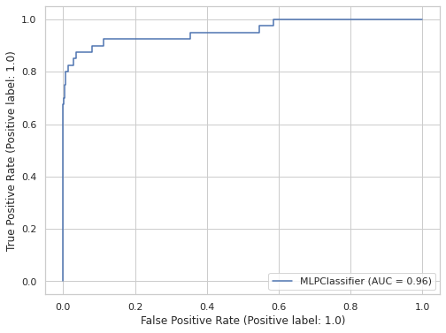

```python
from sklearn.metrics import plot_roc_curve
plot_roc_curve(trained_model, X_test, Y_test)
plt.show()
```

## Comparing false negatives, recall and roc_auc_score

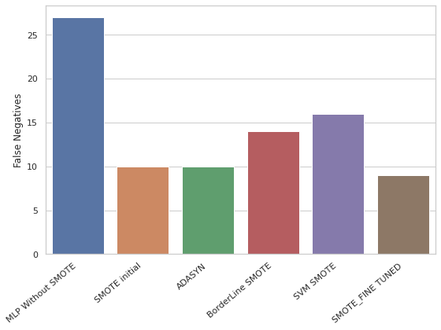

```python
FN = sns.barplot( x = summary.index,y = summary["False Negatives"])
FN.set_xticklabels(FN.get_xticklabels(), rotation=40, ha="right")
plt.tight_layout()
plt.show()
```

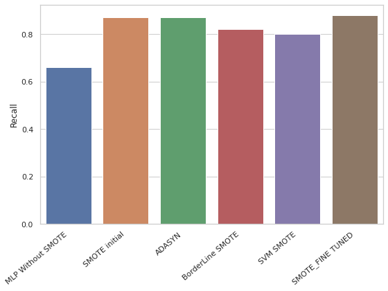

```python
recall = sns.barplot(x = summary.index, y = summary["Recall"])
recall.set_xticklabels(FN.get_xticklabels(), rotation=40, ha="right")
plt.tight_layout()
plt.show()
```

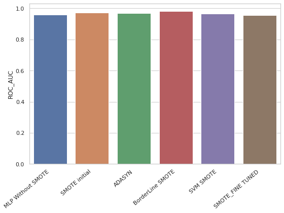

```python
ROC_AUC = sns.barplot(x = summary.index, y = summary["ROC_AUC"])
ROC_AUC.set_xticklabels(FN.get_xticklabels(), rotation=40, ha="right")
plt.tight_layout()
plt.show()
```

The summary shows that SMOTE after fine tuning has the lowest False Negatives and highest Recall. Even though the ROC_AUC score is slightly lesser than the other models, due to the high Recall and low False Negatives, SMOTE after finetuning is chosen as the best model

## Sources

https://machinelearningmastery.com/smote-oversampling-for-imbalanced-classification/

https://medium.com/analytics-vidhya/credit-card-fraud-detection-in-depth-study-evaluating-the-classification-model-a3680a5a5897#:~:text=The%20most%20frequent%20metric%20used,situations%20like%20imbalanced%20class%20datasets.

https://scikit-learn.org/stable/modules/model_persistence.html